# Time Series

A time series is denoted by $y_t$, where $t = 1, 2, 3...$ are the time unit.

## 1. Three Cpmponents of Time Series

To better analyze a time series, we often decompose it into three components: Time trend component (long term direction), Seasonal component (calendar related changes), and the random component.

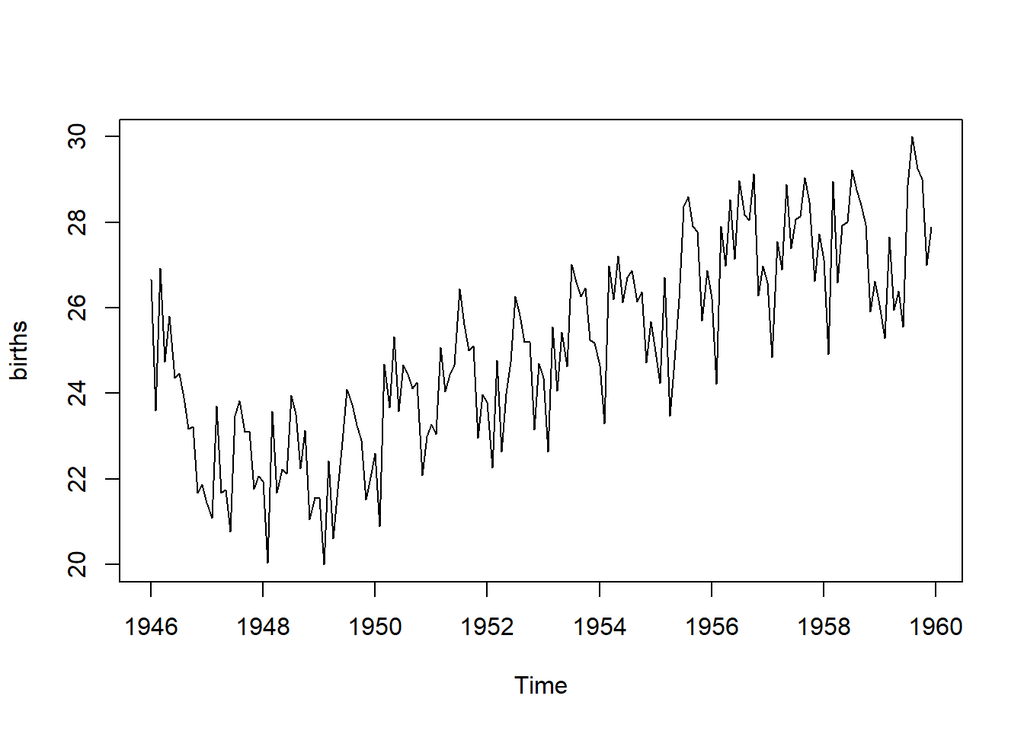

```r
births <- scan("http://robjhyndman.com/tsdldata/data/nybirths.dat")
births <- ts(births, frequency = 12, start = c(1946, 1))
plot(births)
```

A plot shows that this time series has all thee components, trend, seasonal, and random. We decompose this series to see each component individually.

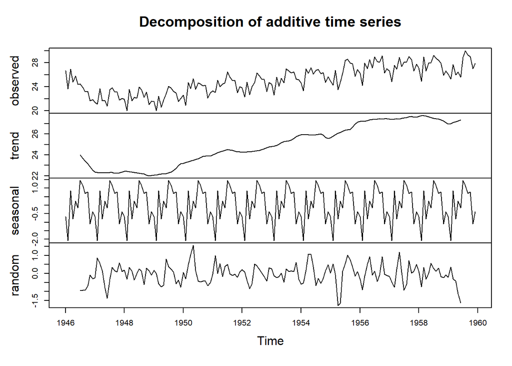

```r
birthsComp <- decompose(births)
plot(birthsComp)
```

## 2. Stationarity

A time series $y_t$ is called stationary if

- 1. $E(y_t)$ does not depend on $t$
- 2. $Cov(y_t, y_s)$ is a function of $|t-s|$

From (2), $var(y_t) = cov(y_t, y_t)$ does not depend on $t$. In general, a stationary series has features that do not depend on the time $t$. Thus, series with seasonal or trend are not stationary series.

## Autocorrelation

We can calculate the correlation of the time series to itself with the one unit time delay. For example, we can calculate the correlation of $(y_1, y_2, ..., y_{9}$ with $(y_2, y_3, ..., y_10)$. This is called a lag 1 autocorrelation $r_1$. More formally,

$$r_1 =
\frac{\sum_{t=2}^T(y_{t-1}-\bar{y})(y_{t}-\bar{y})}{\sum_{t=1}(y_{t}-\bar{y})^2}$$
In general, the lag k autocorrelation is

$$r_k =
\frac{\sum_{t=k+1}^T(y_{t-k}-\bar{y})(y_{t}-\bar{y})}{\sum_{t=1}(y_{t}-\bar{y})^2},$$
for $k=1,2,3...$.

We can consider lag-k autocorrelation as a function of $k$. This function is called autocorrelation function (ACF).

We consider two series: the first one, $a$, with a trend and the second one, $b$, contains just a random component.

$$a_t = 3t+4 + \epsilon, \\
b_t = \epsilon$$
where $\epsilon \sim N(0,1)$.

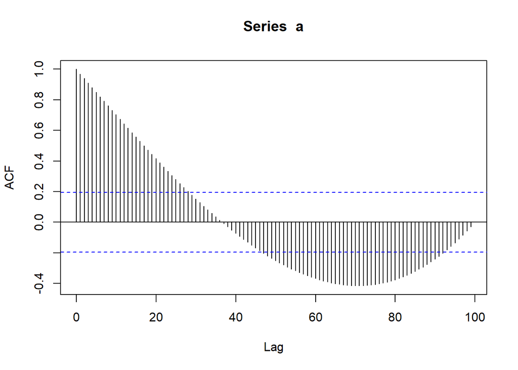

```r
# acf of trend series
n=100
a = rep(0,n)
b = rep(0,n)

for (t in c(1:n))
{
  a[t] = 3*t + 4 + rnorm(0, 1, n=1)
  b[t] = rnorm(0, 1, n=1)

}
acf(a, lag.max = 100)
```

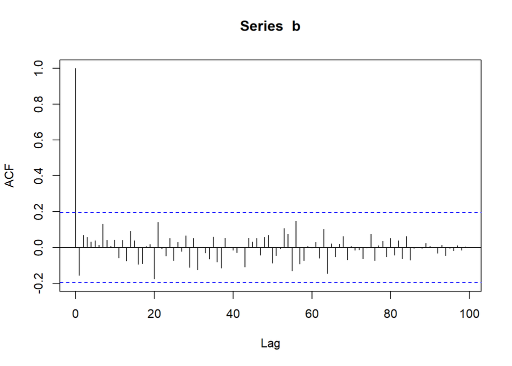

```r
acf(b, lag.max = 100)
```

ACF is a good tool to check if a series is stationary, which is a series $b$ in this case.

## 3. Time Series Models

### 3.1 White Noise

A white noise time series consists of terms that are independent and comes from a identical distribution (iid). The distribution is often assumed to be normal distribution. The mean of the distribution is usually assumed to be zero.

$$\begin{equation}
y_t \overset{\mathrm{iid}}{\sim} N(\mu,\sigma^2)\,
\end{equation}$$

for $t = 1, 2, ...$. A white noise is a stationary series.

### 3.2 Random Walk

A random walk series is a series that has the following form

$$y_t = y_{t-1} + c_t$$
where $c_1, c_2,..., c_T$ are observations of a white noise.

A random walk can be written as

$$y_t = y_0 + c_0 + c_1 + c_2 +...+c_{t}$$

Let’s plot a random walk $y_t = y_{t-1} + \epsilon$ where $y_1 = 1, \epsilon \sim N(0,1)$ and its ACF.

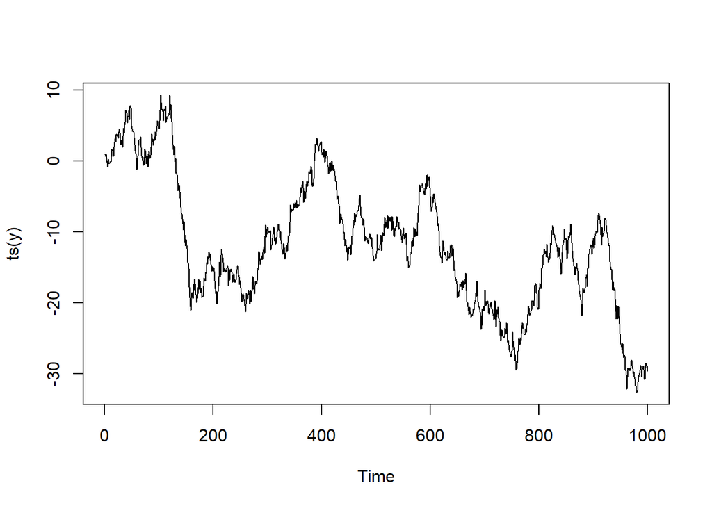

```r
# acf of trend series
n=1000
y = rep(0,n)

y[1] = 1

for (t in c(2:n))
{
  y[t] = y[t-1]+ rnorm(0, 1, n=1)
}
plot(ts(y))
```

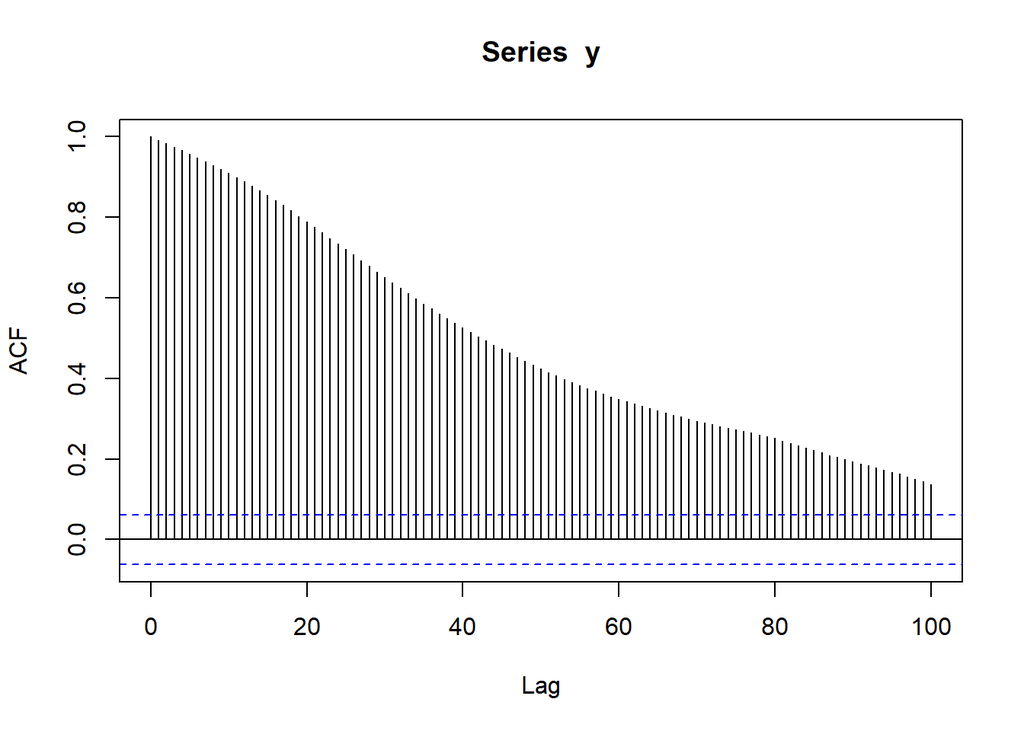

```r
acf(y, lag.max = 100)
```

It can be seen from the ACF that the random walk is non-stationary. In general, random walks are not stationary as its variance depend on the time $t$.

If $c_t \sim (\mu, \sigma^2)$, we have $var(y_t) = (t)\sigma^2$ and $E(y_t) = y_1 + t\mu$. Thus, both the mean and the variance of a random walks may depend on the time $t$.

### 3.3 Autoregressive

The autoregressive model of order 1, denoted by AR(1), is defined by

$$y_t = \beta_0 + \beta_1y_{t-1} + \epsilon,$$
where $\epsilon$ is a white noise process such that $Cov(\epsilon_{t+k}, y_{t})=0$ for $k>0$. $\beta_0$ and $\beta_1$ are parameters (non-random). $-1 \leq \beta_1 \leq 1$.

We notice that if $\beta_1 = 1$, an AR(1) becomes a random walk, and if $\beta_1 = 0$ am AR(1) becomes a white noise.

In the below, we plot autoregressive models for different $\beta_1$ values.

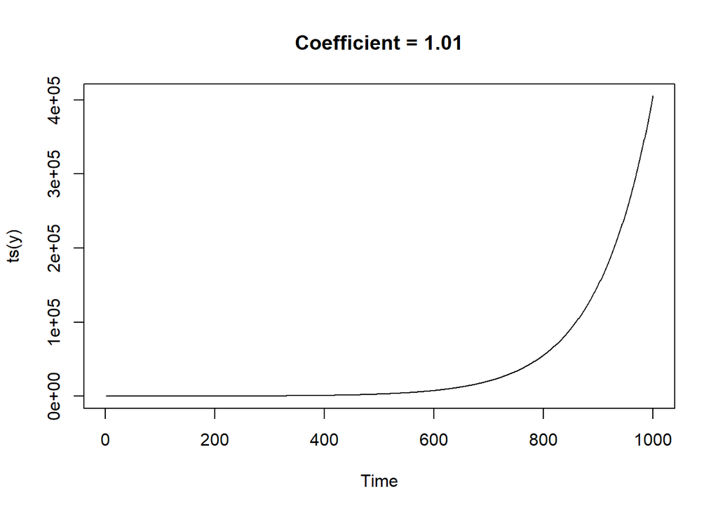

```r
n=1000
y = rep(0,n)
y[1] = 1
for (t in c(2:n))
{
  y[t] = .2+ 1.01*y[t-1]+ rnorm(0, .1, n=1)
}
plot(ts(y))
title(main="Coefficient = 1.01")
```

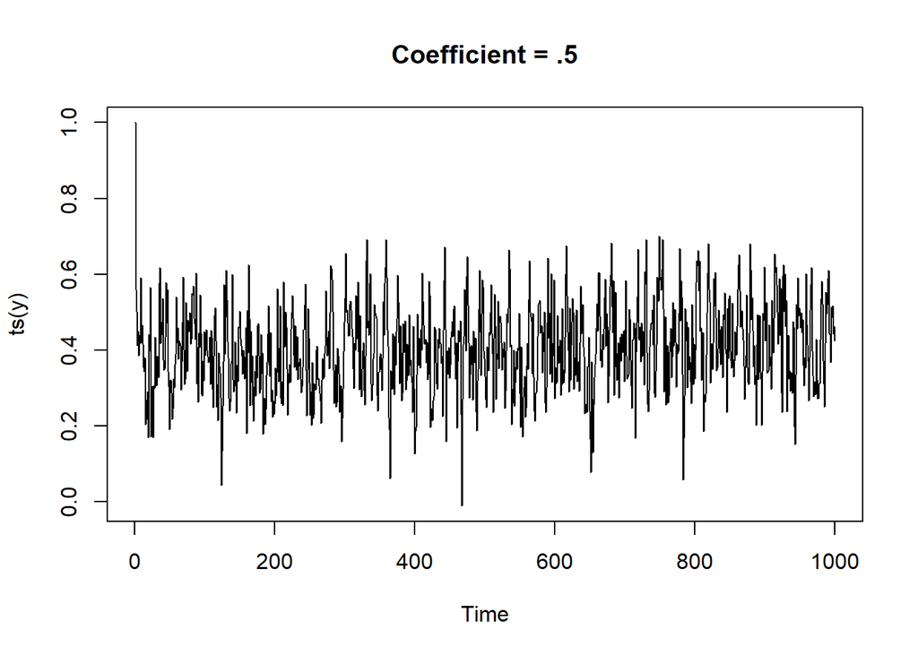

```r
n=1000
y = rep(0,n)
y[1] = 1
for (t in c(2:n))
{
  y[t] = .2+ .5*y[t-1]+ rnorm(0, .1, n=1)
}
plot(ts(y))
title(main="Coefficient = .5")
```

The plot shows that the AR(1) with $\beta_1 = .5$ is a stationary process. This is indeed true for any AR(1) with $-1< \beta_1 < 1$. When $\beta_1 = \pm 1$, the AR(1) is non-stationary.

## 4. Practice Problems